# BST 140.651 Problem Set 3

Kai Aragaki

10/2/2020

# Problem 1

# a

The maximum likelihood can be represented generally as

$\mathcal{L}(\theta|x) = \prod\limits_{i = 1}^nf(x_i,\theta)$

We know that the probability mass function for a Bernoulli random variable $x$ can be written as

$F(X) = \theta^k(1-\theta)^{1-k}$

where $k$ is an indicator value that can take on the value of either $0$ or $1$, where we define $0 = Tails$ and $1 = Heads$.

Therefore,

$\prod\limits_{i = 1}^nf(x_i,\theta) = \theta^7(1-\theta)^{3}$

The maximum likelihood can be solved for by taking the derivative and setting it to zero, then solving for $\theta$.

$(\theta^7(1-\theta)^{3})^\prime = 7\theta^6(1-\theta)^{3} - 3(1-\theta)^{2} = 0$

$\implies \theta = \frac{1}{\frac{3}{7} + 1}$

$\blacksquare$

# b

We can plot the likelihood function:

$\mathcal{L}(\theta|x) = \theta^7(1-\theta)^{3}$

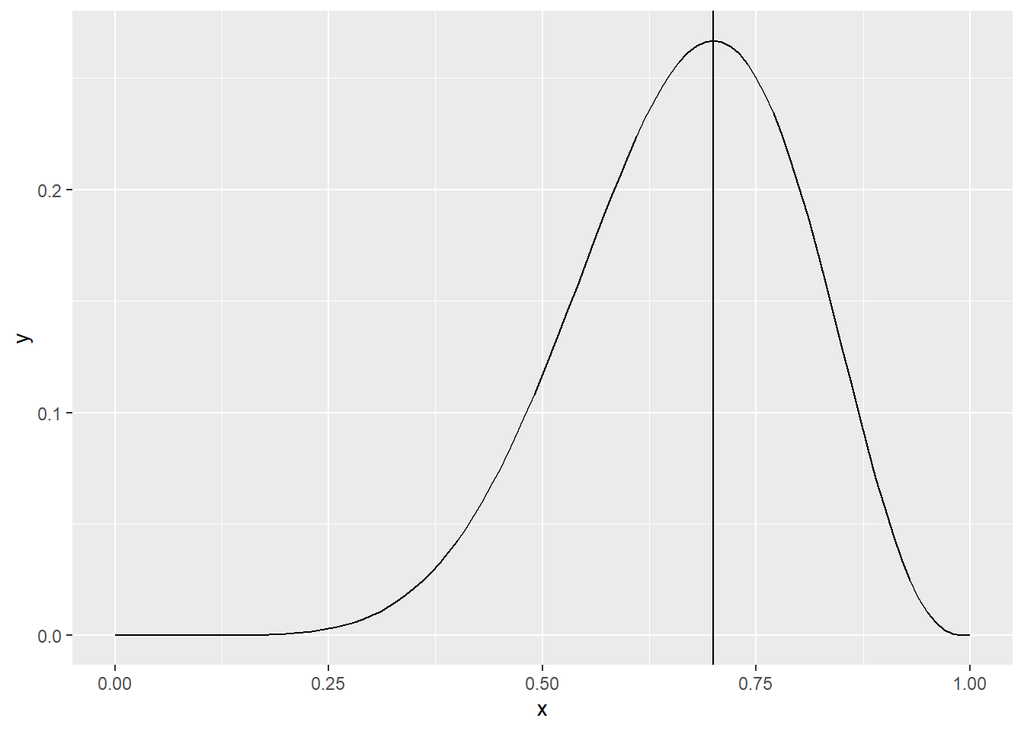

```r
x <- seq(0, 1, by = 0.01)
y <- (factorial(10)/(factorial(3)*factorial(7)))*x^7*(1-x)^3

dat <- tibble(x, y)

ggplot(dat, aes(x, y)) + geom_line() +  geom_vline(xintercept = 1/(3/7 + 1))
```

to re-normalize such that the maximum likelihood is 1, we need to multiply the function by some value such that when $x = ML, y = 1$. First we find what the value of $y$ when it is at its maximum likelihood:

```r
x <- 1/(3/7 + 1)

y <- x^7*(1-x)^3
y
```

```
## [1] 0.002223566
```

And then we divide 1 by this value to solve for the number by which we need to scale:

```r
1/y
```

```
## [1] 449.728
```

so,

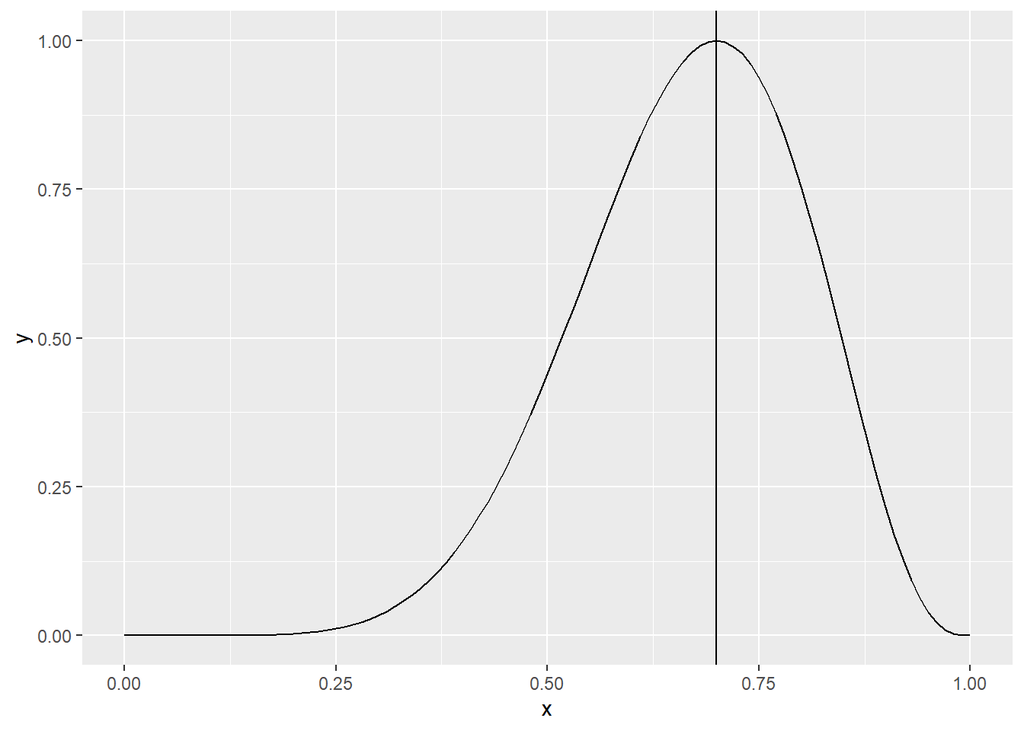

```r
x <- seq(0, 1, by = 0.01)
y <- 449.728*x^7*(1-x)^3

dat <- tibble(x, y)

ggplot(dat, aes(x, y)) + geom_line() +  geom_vline(xintercept = 1/(3/7 + 1))
```

We see that a theta (here written x) of 0.5 (a fair coin) has a likelihood of roughly half that of our maximum likelihood - but this still seems to be within the realm of possibility.

# c

The probability of seeing 7 or more heads given the coin is essentially the integral of the likelihood function from 0.7 to 1 given $\theta = 0.5$. Because this function has a discrete input, this is simply the sum of the values of the PMF from 7 to 10. The PMF is represented by the binomial PMF:

$\sum \limits_{k = 7}^{10}\binom {n}{k} 0.5^k0.5^{10-k} = \frac{10!}{7!3!}0.5^7 0.5^3 + \frac{10!}{8!2!}0.5^8 0.5^2 + \frac{10!}{9!1!}0.5^9 0.5^1 + \frac{10!}{10!0!}0.5^10 0.5^0$

```r
my_sum <- 0
for (k in 7:10) {
        y <- (factorial(10)/(factorial(k)*factorial(10-k)))*(0.5^k) * (0.5^(10-k))
        my_sum <- sum(my_sum + y)
}
my_sum
```

```
## [1] 0.171875
```

Thus, given a fair coin there is a ~17% probability that we would get 7/10 heads (not out of the realm of possibility)

# d

In this particular instance, $y = 10$, so

$\mathcal{L}(p|y) = \frac{9!}{3!7!}(1-p)^3p^7$

We can see that though the constant preceding the function is different, the overall equation remains the same. Therefore the maximum likelihood will be at the same value of x (this constant can be effectively removed upon taking the derivative of this equation and setting it equal to zero)

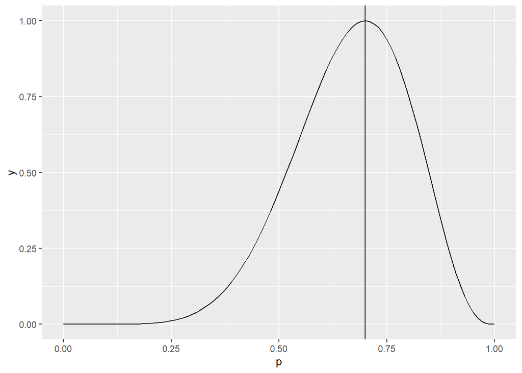

```r
p <- seq(0, 1, by = 0.01)
y <- 449.728*(1-p)^3*p^7

dat <- tibble(p, y)

ggplot(dat, aes(p, y)) + geom_line() + geom_vline(xintercept = 1/(3/7 + 1))
```

```r
my_sum <- 0
for (y in 3:10) {
        y <- (factorial(y-1)/(factorial(2)*factorial(y-2)))*(0.5^y) * (0.5^(y-3))
        my_sum <- sum(my_sum + y)
}
my_sum
```

[output not shown]